# Fisseha Berhane

PhD Candidate, [Department of Earth and Planetary Sciences,](http://eps.jhu.edu/) [Johns Hopkins University](http://jhu.edu)

3400 N. Charles Street, Baltimore, MD 21218, USA • Office: 325 Olin Hall

443-970-2353 fisseha@jhu.edu CV Resume

## Linear and non-linear regression models to predict global temperature

In this post, I used different linear (generalized linear model, ridge-regression, partial least squares, lasso and elastic net) and non-linear (generalized additive model, multivariate adaptive regression spline, support vector machines, random forest, neural network and boosting) regression models to predict global average temperature anomaly. First, I did exploratory data analysis to understand the features and how they can be associated with global temperature then built predicitve models employing various machine learning techniques, assessed the importance of the various independet variables in predicting average global temperature anomaly and compared the performance of the different models considered. The data is aquaired from the MITX Analytics Edge edx course [Website.](https://courses.edx.org/asset-v1:MITx+15.071x_2a+2T2015+type@asset+block/climate_change.csv)

Let's download the data and see the variables in the data set.

```r
# Load required libraries
library(downloader)
require(ggplot2)
library(caret)
library(nnet)
library(NeuralNetTools)
library(dplyr)
library(plotmo)
```

```r
# Download data

url<-"https://courses.edx.org/asset-v1:MITx+15.071x_2a+2T2015+type@asset+block/climate_change.csv"

download(url,dest="climate.csv")

clim = read.csv("climate.csv")

str(clim)
```

```
'data.frame':	308 obs. of  11 variables:
 $ Year    : int  1983 1983 1983 1983 1983 1983 1983 1983 1984 1984 ...
 $ Month   : int  5 6 7 8 9 10 11 12 1 2 ...
 $ MEI     : num  2.556 2.167 1.741 1.13 0.428 ...
 $ CO2     : num  346 346 344 342 340 ...
 $ CH4     : num  1639 1634 1633 1631 1648 ...
 $ N2O     : num  304 304 304 304 304 ...
 $ CFC.11  : num  191 192 193 194 194 ...
 $ CFC.12  : num  350 352 354 356 357 ...
 $ TSI     : num  1366 1366 1366 1366 1366 ...
 $ Aerosols: num  0.0863 0.0794 0.0731 0.0673 0.0619 0.0569 0.0524 0.0486 0.0451 0.0416 ...
 $ Temp    : num  0.109 0.118 0.137 0.176 0.149 0.093 0.232 0.078 0.089 0.013 ...
```

Let's use the data upto 2006 for training and predict for 2007 and 2008. We will not use the variables 'Year' and 'Month' in predicitive model building process.

```r
training<-subset(clim,clim$Year<=2006)
testing<-subset(clim,clim$Year > 2006)

testingX<-subset(clim[,3:10],clim$Year> 2006)
testingY<-subset(clim[,11],clim$Year> 2006)
```

### Exploratory Data Analysis

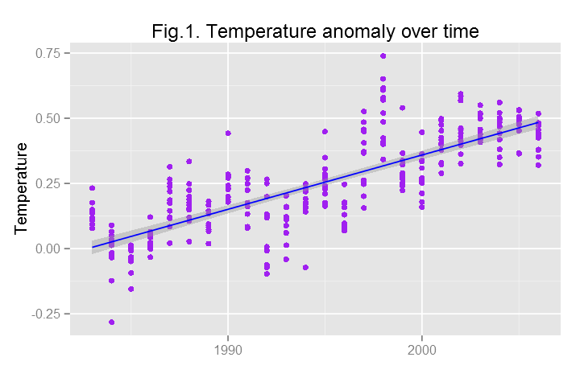

```r
ggplot(training, aes(Year, Temp))+geom_point(color="purple")+
ggtitle('Fig.1. Temperature anomaly over time')+
xlab('')+ylab('Temperature')+
stat_smooth(method=lm, colour='blue',span=0.2)
```

From Fig.1., we see the clear increasing trend of temperature over the data period.

One of the main causes of global temperature increase is asscoaited with inceased carbondioxide emission to the atmosphere from different sources. Let's see the relationship between temperature and carbondiodixe.

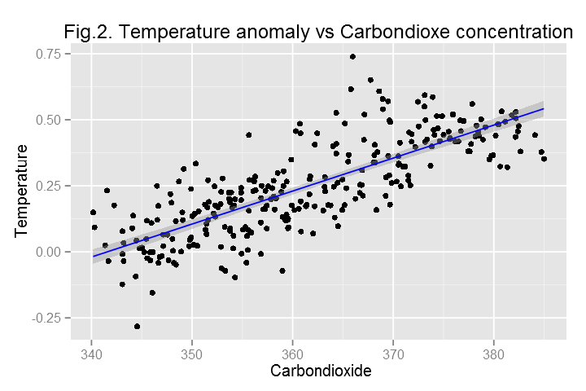

```r
ggplot(training, aes(CO2, Temp))+geom_point()+
ggtitle('Fig.2. Temperature anomaly vs Carbondioxe concentration')+
xlab(' Carbondioxide')+ylab('Temperature')+stat_smooth(method=lm,colour='blue', span=0.2)
```

As shown in Fig.2, carbondioxide and temperature are strongly related.

Following an oscillation in the tropical Pacific Ocean, global tempreature fluctuates. This oscillation is represented by the variable MEI in the dataset. Let's plot the association of temperature anomaly with the MEI index.

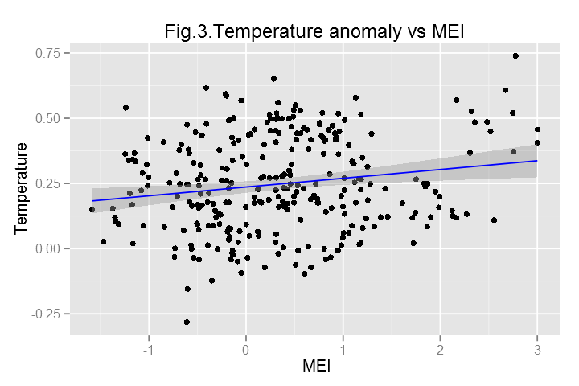

```r
ggplot(training, aes(MEI, Temp))+geom_point()+
ggtitle('Fig.3.Temperature anomaly vs MEI')+xlab(' MEI')+
ylab('Temperature')+stat_smooth(method=lm,colour='blue', span=0.2)
```

The figure does not reveal strong linear association between MEI and average global temperature, however, MEI can have systematic influences on global temperature and it could be an important predictor as we will see later.

## Generalized Linear Model

Let's fit a generalized linear model with the "glm" function and generate variable importance figure, predic on the test data and plot observed values versus predicted values using the ggplot2 package. To access accuracy, let's use repeated k-fold cross-validation (particularly 10-fold cross-validation repeated 5 times).

```
glm variable importance

         Overall
MEI       9.9232
Aerosols  7.2103
TSI       6.3126
CFC.11    4.0778
CFC.12    3.7573
CO2       2.8264
N2O       1.9297
CH4       0.2405
```

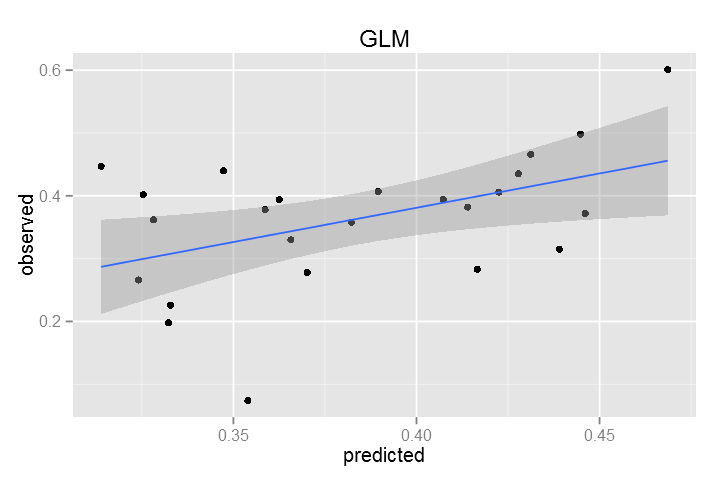

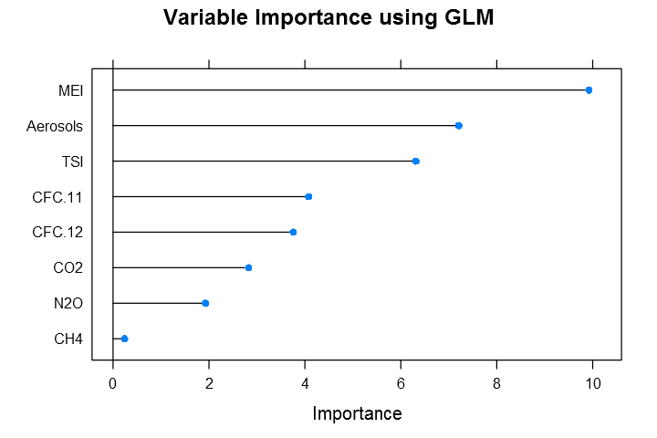

```r
control <- trainControl(method="repeatedcv", number=10, repeats=5)

my_glm <- train(training[,3:10], training[,11],
               method = "glm",
               preProc = c("center", "scale"),
                trControl = control)

# Predict using the test data

pred<-predict(my_glm,testingX)

my_data=as.data.frame(cbind(predicted=pred,observed=testingY))

ggplot(my_data,aes(predicted,observed))+geom_point()+geom_smooth(method=lm)+ggtitle('GLM')

# Print, plot variable importance

print(varImp(my_glm, scale = FALSE))

plot(varImp(my_glm, scale = FALSE), main="Variable Importance using GLM")
```

We can see the summary of the model and understand which features are significant.

```r
summary(my_glm)
```

```
Call:
NULL

Deviance Residuals:
     Min        1Q    Median        3Q       Max
-0.25888  -0.05913  -0.00082   0.05649   0.32433

Coefficients:
             Estimate Std. Error t value Pr(>|t|)
(Intercept)  0.247799   0.005442  45.534  < 2e-16 ***
MEI          0.059688   0.006015   9.923  < 2e-16 ***
CO2          0.073870   0.026136   2.826  0.00505 **
CH4          0.005665   0.023558   0.240  0.81015
N2O         -0.078649   0.040756  -1.930  0.05467 .
CFC.11      -0.139159   0.034126  -4.078 5.96e-05 ***
CFC.12       0.224856   0.059845   3.757  0.00021 ***
TSI          0.037376   0.005921   6.313 1.10e-09 ***
Aerosols    -0.046150   0.006401  -7.210 5.41e-12 ***
---
Signif. codes:  0 '***' 0.001 '**' 0.01 '*' 0.05 '.' 0.1 ' ' 1

(Dispersion parameter for gaussian family taken to be 0.00841098)

    Null deviance: 9.2853  on 283  degrees of freedom
Residual deviance: 2.3130  on 275  degrees of freedom
AIC: -540.2

Number of Fisher Scoring iterations: 2
```

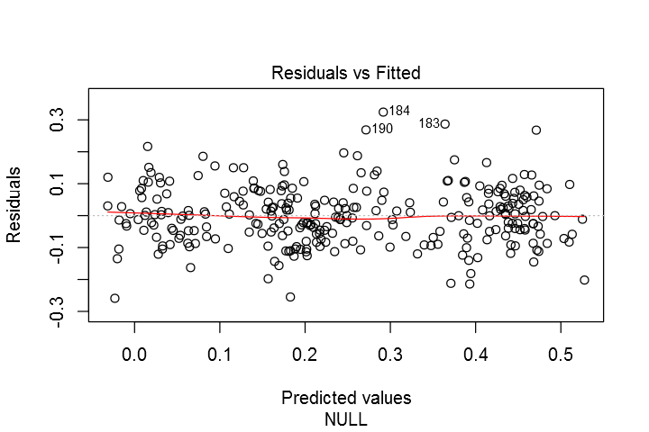

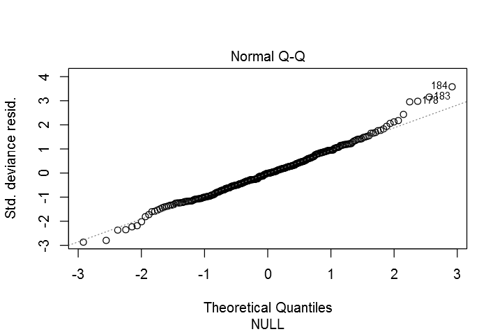

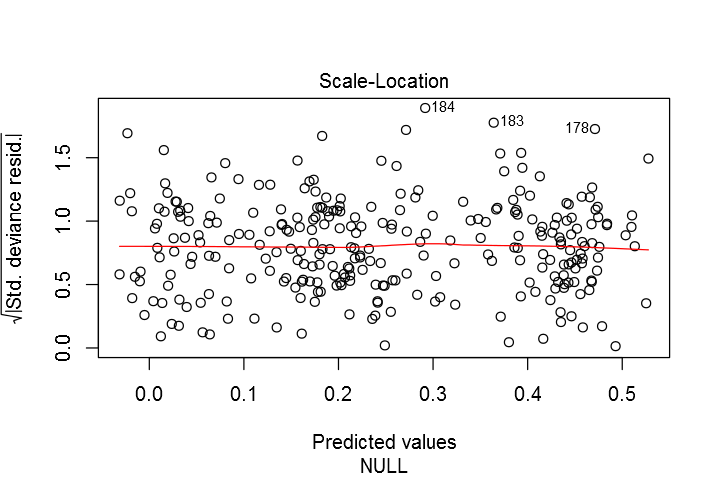

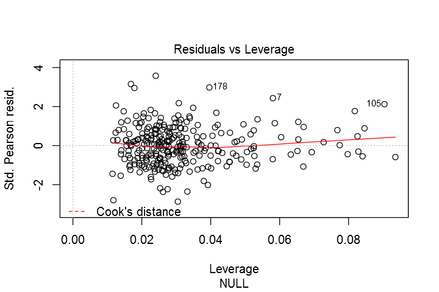

```r
plot(my_glm$finalModel)
```

```
 grid:    MEI    CO2      CH4      N2O   CFC.11  CFC.12      TSI Aerosols
       0.3085 359.89 1758.605 310.8495 260.3735 522.089 1366.054   0.0062
```

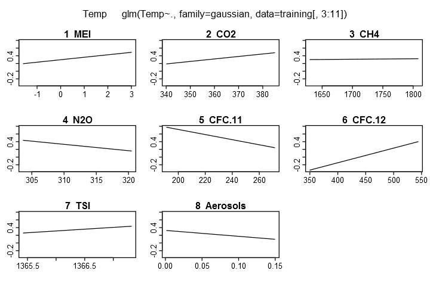

```r
plotmo(glm(Temp~., data=training[,3:11], family=gaussian))
```

## Generalized Linear Model with Stepwise Feature Selection

Now, let's use the [glmStepAIC](http://topepo.github.io/caret/Generalized_Linear_Model.html) method to select important features automatically via Akaike Information Criterion (AIC).

```
loess r-squared variable importance

         Overall
CFC.12   0.64706
CO2      0.64428
N2O      0.62275
Aerosols 0.57937
CH4      0.54393
CFC.11   0.49591
TSI      0.14404
MEI      0.08436
```

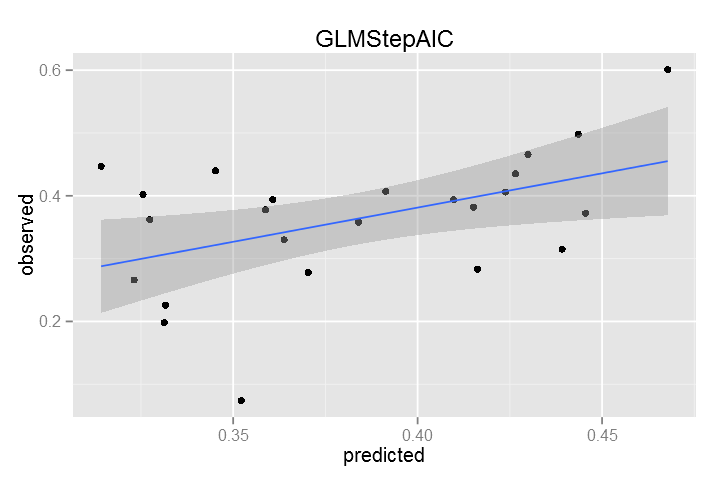

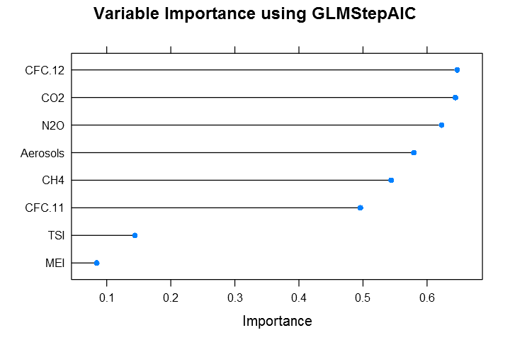

```r
control <- trainControl(method="repeatedcv", number=10, repeats=5)

my_stepglm <- train(training[,3:10], training[,11],
               method = "glmStepAIC",
               preProc = c("center", "scale"),
                trControl = control,verbose=F)

# Predict using the test data

pred<-predict(my_stepglm,testingX)

my_data=as.data.frame(cbind(predicted=pred,observed=testingY))

ggplot(my_data,aes(predicted,observed))+geom_point()+geom_smooth(method=lm)+ggtitle('GLMStepAIC')

# Print, plot variable importance

print(varImp(my_stepglm, scale = FALSE))

plot(varImp(my_stepglm, scale = FALSE), main="Variable Importance using GLMStepAIC")
```

## Partial Least Squares (PLS)

Prior to performing PLS, the predictors should be centered and scaled, especially if the predictors are on scales of differing magnitude. PLS will seek directions of maximum variation while simultaneously considering correlation with the response.

```
pls variable importance

          Overall
CO2      0.030823
N2O      0.030341
CFC.12   0.026560
CH4      0.025814
CFC.11   0.021456
Aerosols 0.018157
MEI      0.014342
TSI      0.009778
```

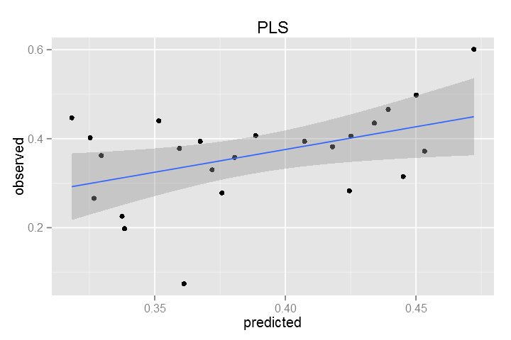

```
Data: 	X dimension: 284 8
	Y dimension: 284 1
Fit method: oscorespls
Number of components considered: 7
TRAINING: % variance explained
          1 comps  2 comps  3 comps  4 comps  5 comps  6 comps  7 comps
X           55.20    64.41    75.94    83.59    96.03    99.46    99.75
.outcome    60.77    73.15    73.86    73.95    74.09    74.49    75.05
```

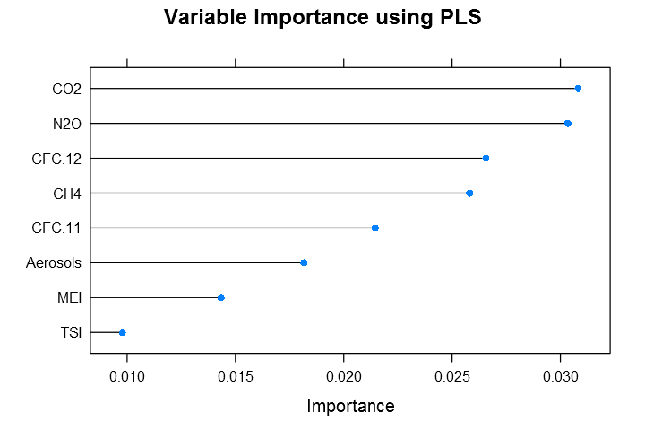

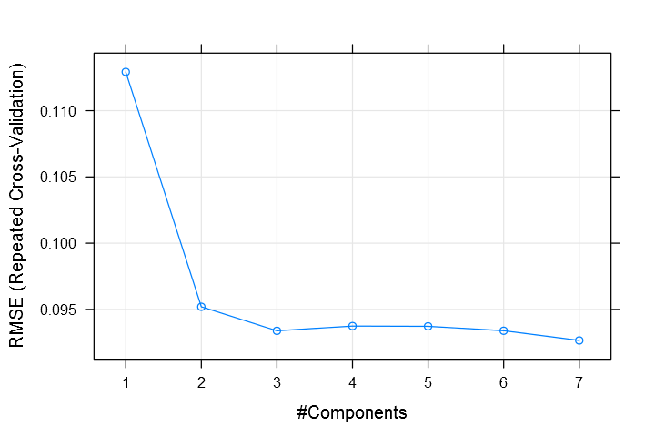

```r
control <- trainControl(method="repeatedcv", number=10, repeats=5)

my_tunedpls <- train(training[,3:10], training[,11],
method = "pls",
## The default tuning grid evaluates
## components 1... tuneLength
tuneLength = 20,
trControl = control,
preProc = c("center", "scale"))

# Predict using test data
pred<-predict(my_tunedpls,testingX)

my_data=as.data.frame(cbind(predicted=pred,observed=testingY))

ggplot(my_data,aes(predicted,observed))+geom_point()+geom_smooth(method=lm)+ggtitle('PLS')

# Print, plot variable importance

print(varImp(my_tunedpls, scale = FALSE))

plot(varImp(my_tunedpls, scale = FALSE), main="Variable Importance using PLS")

summary(my_tunedpls)

plot(my_tunedpls)
```

```r
cat("R-Squared  = ",R2(my_data$predicted, my_data$observed))

cat("\n")

cat("RMSE-Squared  = ",RMSE(my_data$predicted,my_data$observed))
```

[output not shown]

```
RMSE-Squared  =  0.09744475
```

## Penalized linear regression models

### 1. Ridge-regression

```
loess r-squared variable importance

         Overall
CFC.12   0.64706
CO2      0.64428
N2O      0.62275
Aerosols 0.57937
CH4      0.54393
CFC.11   0.49591
TSI      0.14404
MEI      0.08436
```

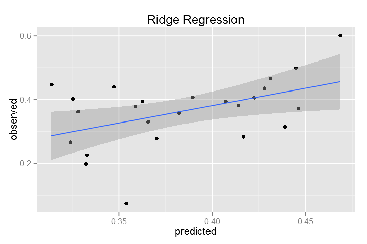

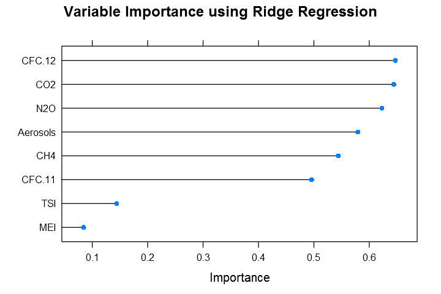

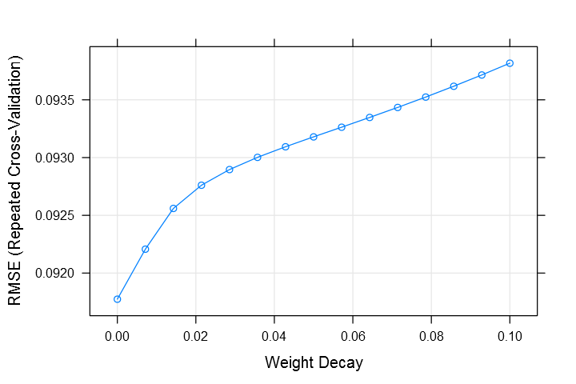

```r
ridgeGrid <- data.frame(.lambda = seq(0, .1, length = 15))

control <- trainControl(method="repeatedcv", number=10, repeats=5)

set.seed(100)

my_ridgeReg <- train(training[,3:10], training[,11],
method = "ridge",

## Fit the model over many penalty values

tuneGrid = ridgeGrid,
trControl = control,

## put the predictors on the same scale
preProc = c("center", "scale"))

# Predict using the test data
pred<-predict(my_ridgeReg,testingX)

my_data=as.data.frame(cbind(predicted=pred,observed=testingY))

ggplot(my_data,aes(predicted,observed))+geom_point()+geom_smooth(method=lm)+ggtitle('Ridge Regression')

# Print, plot variable importance

print(varImp(my_ridgeReg, scale = FALSE))

plot(varImp(my_ridgeReg, scale = FALSE), main="Variable Importance using Ridge Regression")

plot(my_ridgeReg)
```

### 2. Lasso (least absolute shrinkage and selection operator)

```
loess r-squared variable importance

         Overall
CFC.12   0.64706
CO2      0.64428
N2O      0.62275
Aerosols 0.57937
CH4      0.54393
CFC.11   0.49591
TSI      0.14404
MEI      0.08436
```

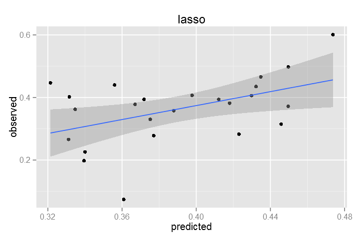

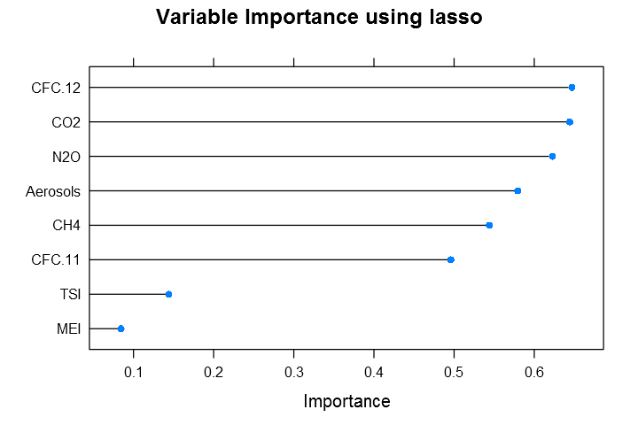

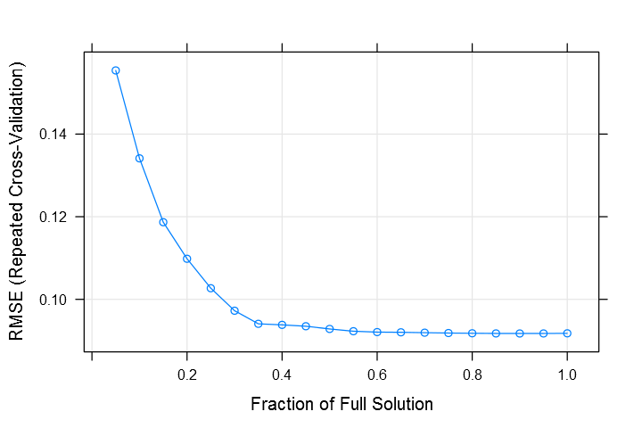

```r
lassoGrid <- expand.grid(.fraction = seq(.05, 1, length = 20))

control <- trainControl(method="repeatedcv", number=10, repeats=5)

set.seed(100)

my_lasso <- train(training[,3:10], training[,11],
method = "lasso",

## Fit the model over many penalty values

tuneGrid = lassoGrid,
trControl = control,

## put the predictors on the same scale
preProc = c("center", "scale"))

# Predict using test data

pred<-predict(my_lasso,testingX)

my_data=as.data.frame(cbind(predicted=pred,observed=testingY))

ggplot(my_data,aes(predicted,observed))+geom_point()+geom_smooth(method=lm)+ggtitle('lasso')

# Print, plot variable importance

print(varImp(my_lasso, scale = FALSE))

plot(varImp(my_lasso, scale = FALSE), main="Variable Importance using lasso")

plot(my_lasso)
```

### 3. Elastic net

```
loess r-squared variable importance

         Overall
CFC.12   0.64706
CO2      0.64428
N2O      0.62275
Aerosols 0.57937
CH4      0.54393
CFC.11   0.49591
TSI      0.14404
MEI      0.08436
```

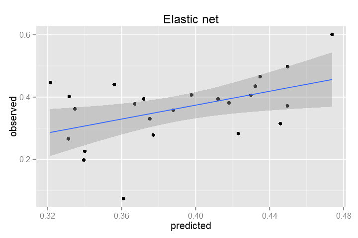

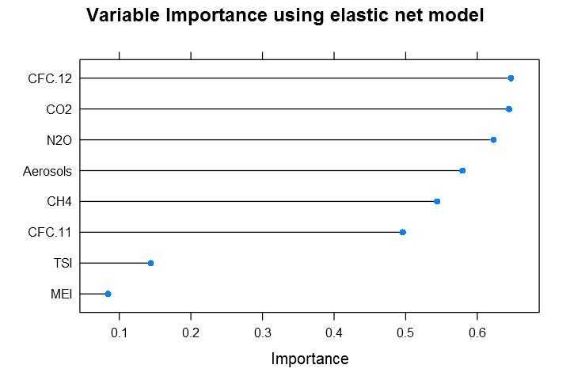

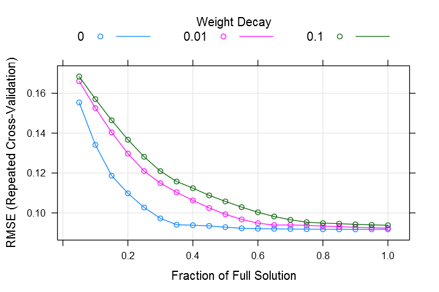

```r
enetGrid <- expand.grid(.lambda = c(0, 0.01, .1),
                 .fraction = seq(.05, 1, length = 20))

control <- trainControl(method="repeatedcv", number=10, repeats=5)

set.seed(100)

my_enet <- train(training[,3:10], training[,11],
method = "enet",

## Fit the model over many penalty values

tuneGrid = enetGrid,
trControl = control,

## put the predictors on the same scale
preProc = c("center", "scale"))

# Predict using the test data

pred<-predict(my_enet,testingX)

my_data=as.data.frame(cbind(predicted=pred,observed=testingY))

ggplot(my_data,aes(predicted,observed))+geom_point()+geom_smooth(method=lm)+ggtitle('Elastic net')

# Print, plot variable importance

print(varImp(my_enet, scale = FALSE))

plot(varImp(my_enet, scale = FALSE), main="Variable Importance using elastic net model")

plot(my_enet)
```

## Non-linear regression models

Now, let's work with non-linear regression models: generalized additive models, multivariate adaptive regression spline,neural network, support vector machines, random forest, boosting, and classification and regression trees.

## Generalized additive models

```
gam variable importance

         Overall
MEI      12.8288
Aerosols  7.7578
N2O       7.1806
CFC.11    6.4214
TSI       2.1891
CO2       1.0403
CFC.12    0.6147
CH4       0.1516
```

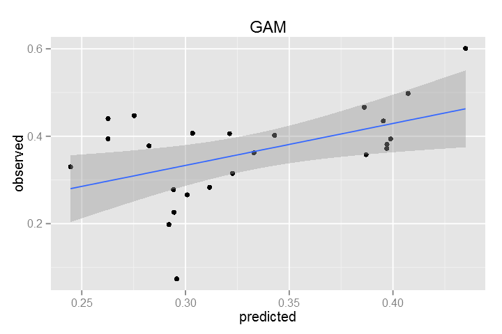

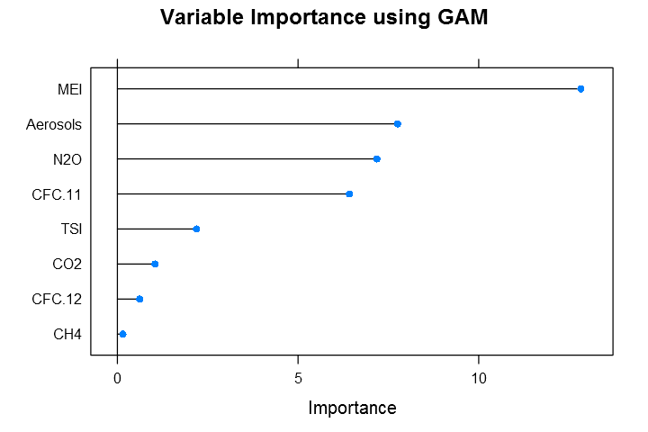

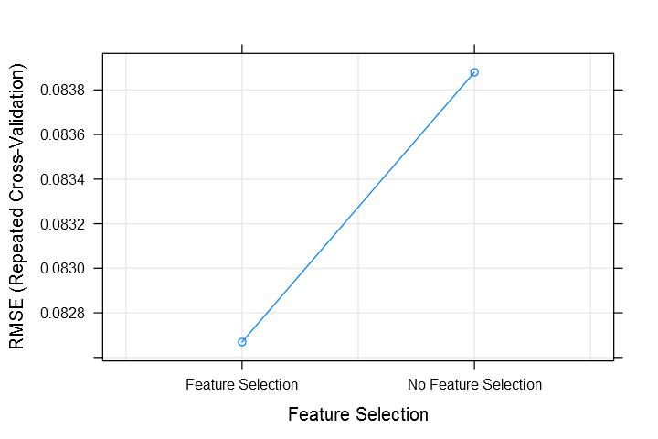

```r
control <- trainControl(method="repeatedcv", number=10, repeats=5)
#spline_control<-expand.grid(.bs=c("cr","cs","cc","tp","tr","sos"))

set.seed(100)

my_gam <- train(training[,3:10], training[,11],
method = "gam", metric = "RMSE",

## Fit the model with repeated CV
trControl = control,bs="cr",

## put the predictors on the same scale
preProc = c("center", "scale"))

# Predict using the test data

pred<-predict(my_gam,testingX)

my_data=as.data.frame(cbind(predicted=pred,observed=testingY))

ggplot(my_data,aes(predicted,observed))+geom_point()+geom_smooth(method=lm)+ggtitle('GAM')

# Print, plot variable importance

print(varImp(my_gam, scale = FALSE))

plot(varImp(my_gam, scale = FALSE), main="Variable Importance using GAM")

plot(my_gam)
```